# Cyber Security MOOC Analysis

Tanish Vikas Newale - 250204944

January 2026

**1. Introduction**

Massive Open Online Courses (MOOCs) have become a strategic tool for universities to expand global reach, enhance brand visibility, and support lifelong learning. In technical domains such as Cyber Security, MOOCs also play a critical role in addressing global skill shortages by providing accessible, flexible learning opportunities to diverse learner groups.

This report presents an in-depth analysis of learner data from the Newcastle University Cyber Security MOOC. The primary aim is to extract actionable insights that can support academic planners, marketing teams, and course designers in improving learner targeting, inclusivity, and retention. The analysis is structured using the CRISP-DM (Cross Industry Standard Process for Data Mining) framework, ensuring a systematic and industry-recognized approach to data-driven decision-making.

**2. Methodological Framework: CRISP-DM**

CRISP-DM provides a structured six-phase lifecycle for data analytics projects: Business Understanding, Data Understanding, Data Preparation, Modelling, Evaluation, and Deployment. For clarity and relevance, this report focuses on two complete analytical cycles:

Cycle 1: Learner Demographics

Cycle 2: Diversity and Engagement

**CRISP-DM Cycle 1: Learner Demographics** **2.1 Business Understanding**

Objective: To identify the geographical distribution and age profile of learners enrolled in the Cyber Security MOOC.

Strategic Importance: Understanding who the learners are and where they come from is essential for:

Designing culturally and professionally relevant course content

Selecting appropriate examples, case studies, and assessment styles

Informing international marketing and recruitment strategies

Aligning course difficulty with learner maturity and professional experience

For a globally offered MOOC, demographic insights directly influence both academic quality and commercial sustainability.

**2.2 Data Understanding**

Data Sources: The analysis draws on enrolment datasets generated during the MOOC registration process. Key variables include:

Country of residence

Age or age range

Gender

Data Quality Considerations: Initial exploration revealed the presence of missing, blank, or “Unknown” values within demographic fields. These entries were systematically filtered out to ensure that:

Aggregate trends are not distorted

Visualisations accurately reflect active and identifiable learners

Conclusions remain statistically and conceptually valid

This step ensures analytical integrity before any modelling or interpretation is performed.

The country-level analysis highlights a strong international footprint for the course. The highest concentration of learners originates from:

United Kingdom (GB)

India (IN)

Other countries such as the United States, Nigeria, and Australia also feature prominently, indicating interest from both developed and emerging economies.

**Interpretation:**

High UK participation suggests effective domestic outreach and strong institutional brand recognition

Significant enrolment from India and Nigeria reflects demand for cyber security skills in fast-growing digital economies

The diversity of countries indicates the MOOC’s success as a global learning product

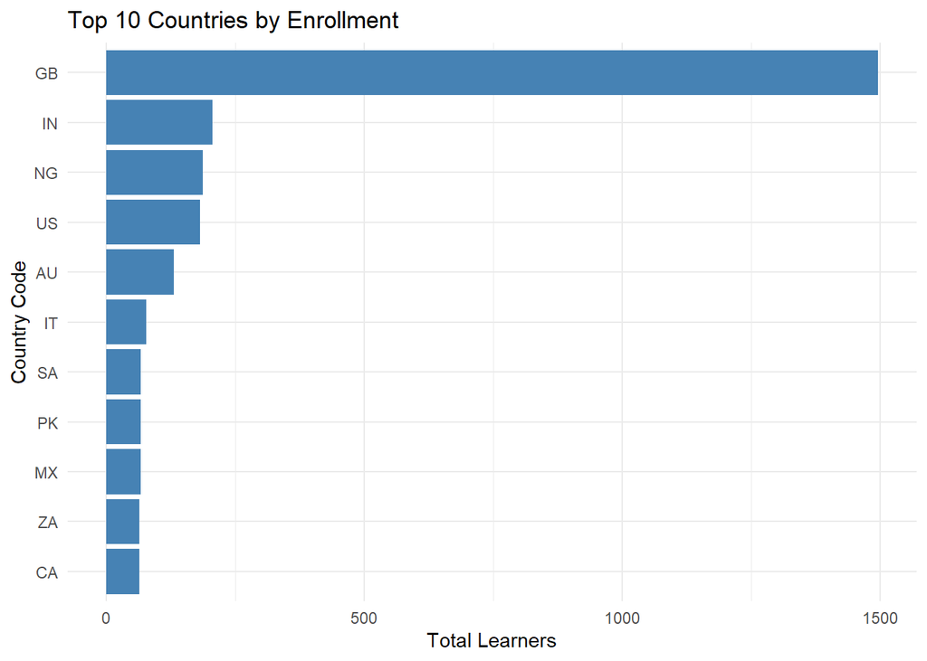

**Visualization 2: Age Distribution of Learners**

Interpretation:

Learners are likely motivated by career progression, reskilling, or role transition

Course pacing, assessment complexity, and applied content are well aligned with professional learners rather than purely academic audiences

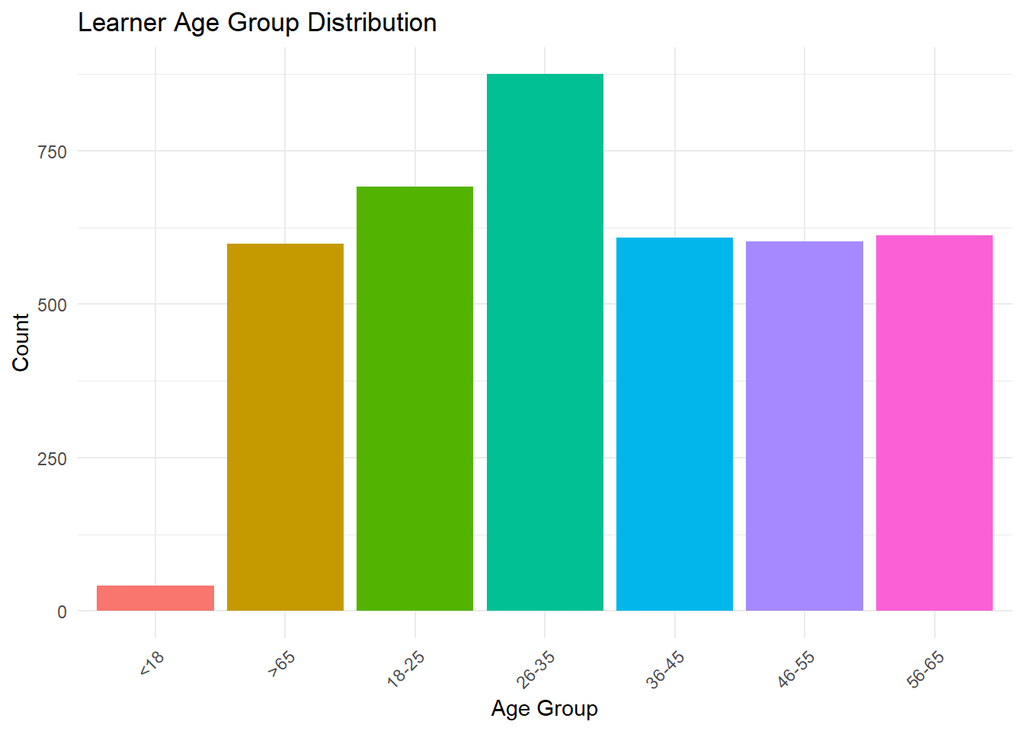

**2.4 Evaluation (Cycle 1)**

Cycle 1 confirms that the Cyber Security MOOC predominantly serves a global, professional, and career-oriented audience. The geographic and age patterns validate the course’s positioning as a practical and industry-relevant programme rather than an introductory academic course.

These insights establish a foundation for deeper analysis into learner inclusivity and behavioural engagement.

2. Modeling (Visualizations)

Visualization 3: Gender Diversity

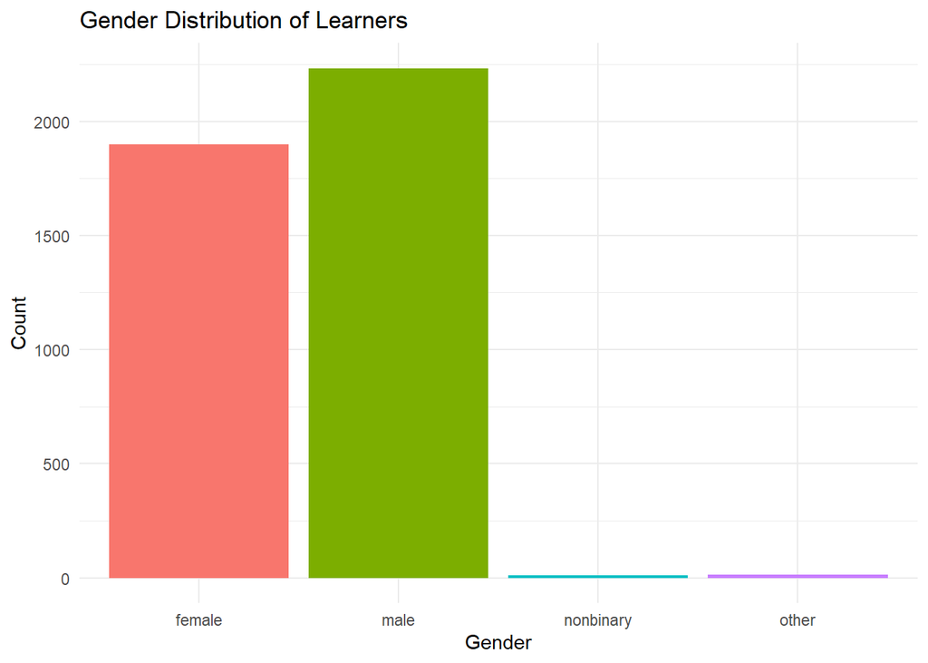

Visualization 4: Weekly Engagement

[figure not shown]

**4. Conclusion**

This analysis demonstrates how structured data analytics can support evidence-based decision-making in higher education. By applying the CRISP-DM framework, the report systematically transforms raw enrolment and activity data into strategic insights.

Overall, this study highlights the value of combining robust technical analysis with rich theoretical interpretation to inform meaningful organisational action.